# IE360 Project Report

# Group 11

# Burak Nur Erdem

## 1. Introduction

## 2. Analysis of The Data, Followed by the Approach

## 3. Evaluating the Results

## 4. Conclusions and Comments

## 5. Github Link for Forecasting Code Alone

# 1. Introduction

In this project, we are expected to forecast the hourly electricity consumption of Turkey for the period between 30 January and 13 February 2021. The electricity data is taken from the Epias Energy Exchange Transparency Platform. It is in the form of hourly electricity consumption (MWh) starting from 1 January 2017 up to the moment, the last hours are added very soon after they have been observed.

This report goes in paralel with the code written for forecasting in order to ease the observers' understanding of the code and the applied approaches and to support the ideas with graphs and codes. The code can also be accessed apart from the report and comments, given at the end of the report.

# 2. Analysis of The Data, Followed by the Approach

The data shows that the daily aggregate consumption is highly similar in the same weekdays exhibiting a pattern of days in a week. Also, the consumption is highly affected by the temperature levels. In order to demonstrate, there are two graphs below.

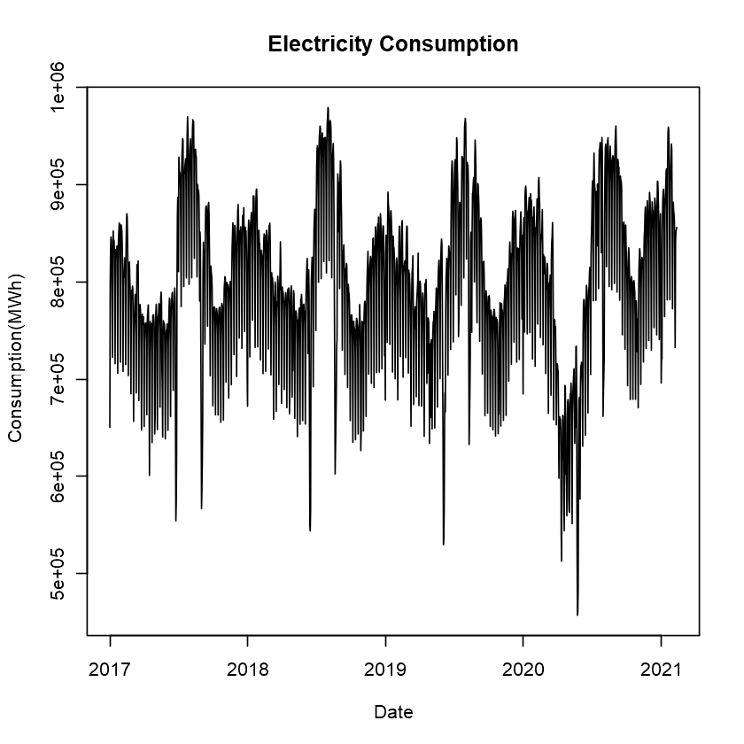

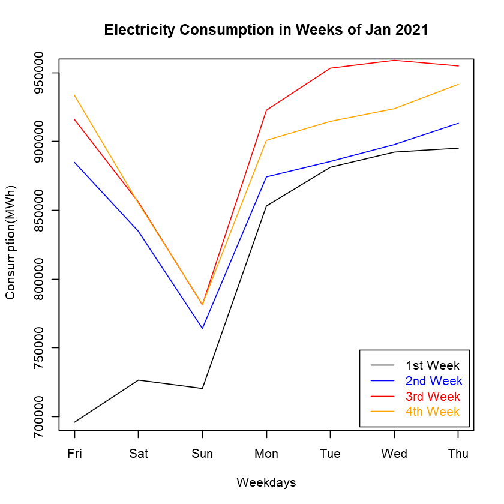

```r
suppressWarnings(suppressMessages(library(data.table)))
suppressWarnings(suppressMessages(library(forecast)))
suppressWarnings(suppressMessages(library(lubridate)))

consump = fread("RealTimeConsumptionProject.csv")
colnames(consump) = c("Date", "Hour", "Consumption")


consump[,Date:=as.Date(consump[,Date], format = "%d.%m.%Y")]
consump[,Consumption:=gsub(',','',Consumption)]
consump[,Consumption:=as.numeric(consump[,Consumption])]

dailycons = consump[,list(DailyConsumption = sum(Consumption)), by = list(Date)]

plot(x=dailycons$Date,y=dailycons$DailyConsumption, type="l",
     ylab="Consumption(MWh)", xlab="Date", main = "Electricity Consumption")

plot(x=dailycons[Date >= as.Date("2021-01-01") & Date <= as.Date("2021-01-07"), Date],
    y= dailycons[Date >= as.Date("2021-01-01") & Date <= as.Date("2021-01-07"), DailyConsumption],
    xlab="Weekdays", ylab="Consumption(MWh)", main = "Electricity Consumption in Weeks of Jan 2021",
    type="l", ylim=c(700000,950000))
lines(x=dailycons[Date >= as.Date("2021-01-01") & Date <= as.Date("2021-01-07"), Date],
    y= dailycons[Date >= as.Date("2021-01-08") & Date <= as.Date("2021-01-14"), DailyConsumption],
     col = "blue")
lines(x=dailycons[Date >= as.Date("2021-01-01") & Date <= as.Date("2021-01-07"), Date],
    y= dailycons[Date >= as.Date("2021-01-15") & Date <= as.Date("2021-01-21"), DailyConsumption],
     col = "red")
lines(x=dailycons[Date >= as.Date("2021-01-01") & Date <= as.Date("2021-01-07"), Date],
    y= dailycons[Date >= as.Date("2021-01-22") & Date <= as.Date("2021-01-28"), DailyConsumption],
     col = "orange")
legend("bottomright", col = c("black", "blue", "red", "orange"), text.col = c("black", "blue", "red", "orange")
       , legend = c("1st Week", "2nd Week", "3rd Week", "4th Week"),
       inset = c(0.01, 0.01), lty = c(1,1,1,1))
```

The first graph shows the movement of the data in the bigger scale. The bigger peaks represent the summer times and the lower peaks represent the winter times. Also, the low consumption due to bans of going out during the Covid 19 period can be seen. There are also a few outliers which are the special holidays and the weekends that are connected such as Ramadan and Kurban Bayrams, 29 October Republic Day, New Year's Eve etc.

In the second graph the pattern of weeks can be seen. It shows that behavior of the weeks that are close to each other are very similar which will be crucial in the modeling. Also the behavior of The New Year's Eve can be seen and shows that the special days require special approaches when modelling.

There is also a problem which is the need to model the hourly consumption instead of daily aggregate consumption. But as you can see in the plot below, in the same weekdays, distribution of daily consumption between hours is highly similar.

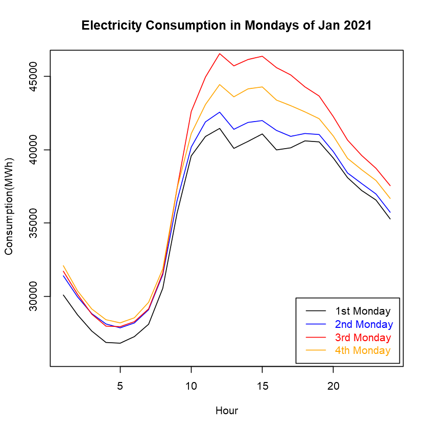

```r
plot(consump[Date == as.Date("2021-01-04"), Consumption], xlab = "Hour", type = "l",
     ylab="Consumption(MWh)", main = "Electricity Consumption in Mondays of Jan 2021",
    ylim=c(26000,46000))
lines(consump[Date == as.Date("2021-01-11"), Consumption], col = "blue")
lines(consump[Date == as.Date("2021-01-18"), Consumption], col = "red")
lines(consump[Date == as.Date("2021-01-25"), Consumption], col = "orange")
legend("bottomright", col = c("black", "blue", "red", "orange"), text.col = c("black", "blue", "red", "orange")
       , legend = c("1st Monday", "2nd Monday", "3rd Monday", "4th Monday"),
       inset = c(0.01, 0.01), lty = c(1,1,1,1))
```

As stated above, the hours of weekdays that are not very far from each other show similar behavior. Also, the goal of the project being to forecast a time interval that is nearly 2 weeks, I have chosen to build the forecast model on an aggregate daily consumption level and divide it into the hours deterministically using the past data.

I have assumed that the hours of same weekdays behave similar. In order to implement this, I have divided each hour's consumption to its daily aggregate level, so that a rate is given that if you multiply that rate with the daily consumption, you would find the consumption of that hour. I have done this for the days after 4 January and took the mean of the rates. In the second week of the forecasting period, I moved the starting period of the considerated days in this method to 11 January. The starting date could be tweaked as a parameter for better results, but I believe that changes would be minimal.

If the forecasting period was longer or all year long, a more complex or more dynamic method than the method I explained or hybrid methods could be followed, but this method I used gives good results that are adequately close if the daily level is forecasted also close.

I have some ideas on how this method could be improved. For example, an algorithm that would search for the hours of same weekdays' hours and decide on the change on the consumption considering the observed temperature values of the past hours and the forecasted temperature of the target hours. If I wasn't so busy in the final exams period, I would like to study on such an algorithm.

The below is the code for the calculation of the multipliers for the hours of each weekdays.

```r
hourMultipliers = data.table(Hour = consump[Date == as.Date("2020-01-01"), Hour])

hourMultipliers[,c("Sunday", "Monday", "Tuesday", "Wednesday", "Thursday", "Friday", "Saturday"):=0]

# First loop is for the weekdays and the second is for the hours.
for(j in 1:7){
    for(i in 0:23){
    hourMultipliers[i+1, j+1] = mean( consump[hm(Hour) == hm("00:00") + hours(i) & wday(Date) == j & Date >= as.Date("2021-01-11"), Consumption] /
                                         consump[wday(Date) == j & Date >= as.Date("2021-01-11"), sum(Consumption), by=Date]$V1
                                         )
        # Changed the start date of the considerated data from 4 jan to 11 jan in 8 feb.
    }
}

hourMultipliers
```

| Hour | Sunday | Monday | Tuesday | Wednesday | Thursday | Friday | Saturday |
| --- | --- | --- | --- | --- | --- | --- | --- |
| 00:00 | 0.04282885 | 0.03566850 | 0.03797125 | 0.03791234 | 0.03785244 | 0.03819971 | 0.04105782 |
| 01:00 | 0.04051146 | 0.03387444 | 0.03609275 | 0.03590033 | 0.03587138 | 0.03614586 | 0.03887481 |
| 02:00 | 0.03861205 | 0.03247768 | 0.03457957 | 0.03449997 | 0.03449641 | 0.03471263 | 0.03734084 |
| 03:00 | 0.03748985 | 0.03163813 | 0.03368922 | 0.03359688 | 0.03358186 | 0.03385463 | 0.03624568 |
| 04:00 | 0.03691314 | 0.03146982 | 0.03342256 | 0.03332469 | 0.03336305 | 0.03356532 | 0.03577154 |
| 05:00 | 0.03666260 | 0.03176969 | 0.03360434 | 0.03357215 | 0.03360249 | 0.03390290 | 0.03571917 |
| 06:00 | 0.03668366 | 0.03281790 | 0.03456420 | 0.03439680 | 0.03447392 | 0.03477696 | 0.03615070 |
| 07:00 | 0.03644811 | 0.03546102 | 0.03642502 | 0.03644918 | 0.03650958 | 0.03675245 | 0.03680278 |
| 08:00 | 0.03622689 | 0.04149816 | 0.04139535 | 0.04126083 | 0.04157678 | 0.04177222 | 0.03902454 |
| 09:00 | 0.03841722 | 0.04597150 | 0.04534719 | 0.04524467 | 0.04536668 | 0.04584742 | 0.04168010 |
| 10:00 | 0.04094983 | 0.04812709 | 0.04716125 | 0.04702595 | 0.04719983 | 0.04790976 | 0.04368937 |
| 11:00 | 0.04297185 | 0.04944258 | 0.04816338 | 0.04797544 | 0.04806439 | 0.04884604 | 0.04542818 |
| 12:00 | 0.04372260 | 0.04825841 | 0.04688043 | 0.04679572 | 0.04678085 | 0.04727519 | 0.04511001 |
| 13:00 | 0.04436700 | 0.04863614 | 0.04718307 | 0.04717807 | 0.04687446 | 0.04606799 | 0.04590507 |
| 14:00 | 0.04428494 | 0.04870381 | 0.04740299 | 0.04746177 | 0.04731923 | 0.04688055 | 0.04577167 |
| 15:00 | 0.04367094 | 0.04782288 | 0.04654237 | 0.04662617 | 0.04650006 | 0.04615699 | 0.04492413 |
| 16:00 | 0.04367170 | 0.04729337 | 0.04600362 | 0.04620159 | 0.04601418 | 0.04562005 | 0.04439463 |
| 17:00 | 0.04433371 | 0.04696504 | 0.04581224 | 0.04593098 | 0.04582096 | 0.04546847 | 0.04443603 |
| 18:00 | 0.04641156 | 0.04667998 | 0.04571920 | 0.04583904 | 0.04567067 | 0.04531920 | 0.04563053 |
| 19:00 | 0.04678448 | 0.04557355 | 0.04478212 | 0.04499287 | 0.04513088 | 0.04443675 | 0.04531026 |
| 20:00 | 0.04593320 | 0.04393239 | 0.04325323 | 0.04341427 | 0.04349764 | 0.04294622 | 0.04411277 |
| 21:00 | 0.04488254 | 0.04298004 | 0.04236435 | 0.04245953 | 0.04247283 | 0.04206612 | 0.04324386 |
| 22:00 | 0.04428060 | 0.04216845 | 0.04154683 | 0.04168874 | 0.04168966 | 0.04134609 | 0.04240602 |
| 23:00 | 0.04294121 | 0.04076944 | 0.04009347 | 0.04025203 | 0.04026975 | 0.04013049 | 0.04096950 |

### Dealing with Outliers

The way I have dealt with the outliers is that, first I have looked at the big valued residuals (which i will not include the code) and the results were the same as the initial assumption which was the special days being the outliers. I have confirmed the dates on the calendar.

Then, I replaced the consumption values of those days with the values of the same weekdays a week before them. This baseline approach could be problematic when modeling those special days; however, our forecast period doesn't include any special days which we need to model, so we can remove them and hope for better estimates of coefficient of parameters which would help our forecasts to be more accurate.

Below, I have written a function to ease the job and put the identified days as to be changed.

The plot after the code shows the daily data which is hopefully, adequately free of outliers.

```r
baselineFill = function(x){
    x = as.Date(x)
    dailycons[Date == x , DailyConsumption:=dailycons[Date == x - days(7) , DailyConsumption]]
}

# 2017 Ramazan Bayramı Value Correction
baselineFill("2017-06-24")
baselineFill("2017-06-25")
baselineFill("2017-06-26")
baselineFill("2017-06-27")

# 2017 Kurban Bayramı Value Correction
baselineFill("2017-08-31")
baselineFill("2017-09-01")
baselineFill("2017-09-02")
baselineFill("2017-09-03")
baselineFill("2017-09-04")

# 2018 Ramazan Bayramı Value Correction
baselineFill("2018-06-14")
baselineFill("2018-06-15")
baselineFill("2018-06-16")
baselineFill("2018-06-17")

# 2018 Kurban Bayramı Value Correction
baselineFill("2018-08-18")
baselineFill("2018-08-19")
baselineFill("2018-08-20")
baselineFill("2018-08-21")
baselineFill("2018-08-22")
baselineFill("2018-08-23")
baselineFill("2018-08-24")
baselineFill("2018-08-25")
baselineFill("2018-08-26")

# 2019 Ramazan Bayramı Value Correction
baselineFill("2019-06-01")
baselineFill("2019-06-02")
baselineFill("2019-06-03")
baselineFill("2019-06-04")
baselineFill("2019-06-05")
baselineFill("2019-06-06")
baselineFill("2019-06-07")
baselineFill("2019-06-08")
baselineFill("2019-06-09")

# 2019 Kurban Bayramı Value Correction
baselineFill("2019-08-10")
baselineFill("2019-08-11")
baselineFill("2019-08-12")
baselineFill("2019-08-13")
baselineFill("2019-08-14")

# 2020 Ramazan Bayramı Value Correction
baselineFill("2020-05-22")
baselineFill("2020-05-23")
baselineFill("2020-05-24")
baselineFill("2020-05-25")
baselineFill("2020-05-26")
baselineFill("2020-05-27")

# 2020 Kurban Bayramı Value Correction
baselineFill("2020-07-30")
baselineFill("2020-07-31")
baselineFill("2020-08-01")
baselineFill("2020-08-02")
baselineFill("2020-08-03")

# Correction of some holidays and near days
# I checked whether they had significantly low values.
baselineFill("2017-05-01")
baselineFill("2017-05-19")
baselineFill("2017-05-20")
baselineFill("2017-08-30")

baselineFill("2018-01-01")
baselineFill("2018-04-23")
baselineFill("2018-04-30")
baselineFill("2018-05-01")
baselineFill("2018-08-30")
baselineFill("2018-10-29")
baselineFill("2018-12-31")

baselineFill("2019-01-01")
baselineFill("2019-04-23")
baselineFill("2019-05-01")
baselineFill("2019-07-15")
baselineFill("2019-08-30")
baselineFill("2019-08-31")
baselineFill("2019-10-28")
baselineFill("2019-10-29")
baselineFill("2019-12-31")

baselineFill("2020-01-01")
baselineFill("2020-04-23")
baselineFill("2020-05-18")
baselineFill("2020-05-19")
baselineFill("2020-05-01")

baselineFill("2021-01-01")
baselineFill("2021-01-02")
```

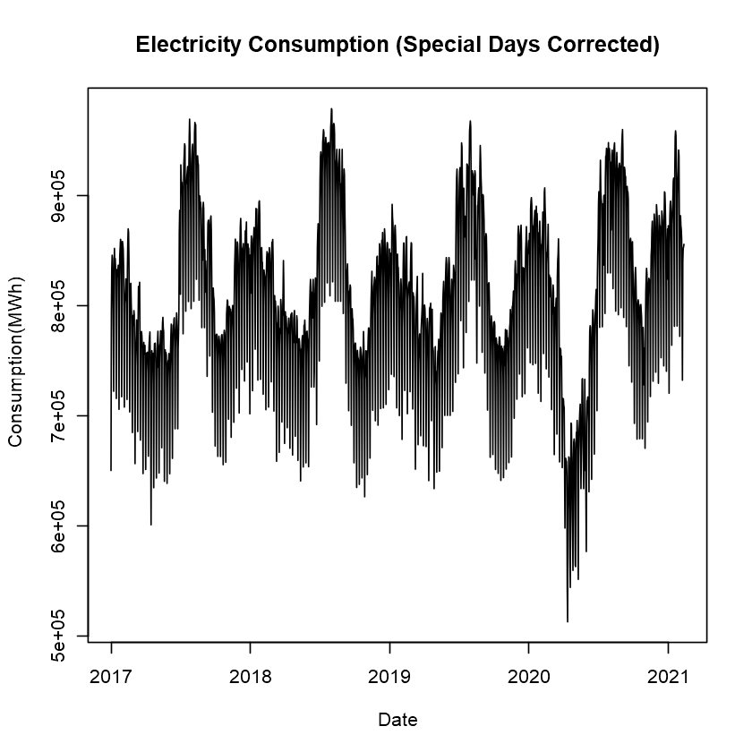

```r
plot(x=dailycons$Date,y=dailycons$DailyConsumption, type="l",
     ylab="Consumption(MWh)", xlab="Date", main = "Electricity Consumption (Special Days Corrected)")
```

### Forecasting the Daily Aggregate Level

I have thought about modeling the daily aggregate consumption with time series models. I've thought that same weekdays are similar and the last days include some information about the next days. This could be modeled well with seasonal ARIMA models.

In order to obtain some ideas about the daily consumption levels and seasonality of weekdays, we can look at the auto correlation function.

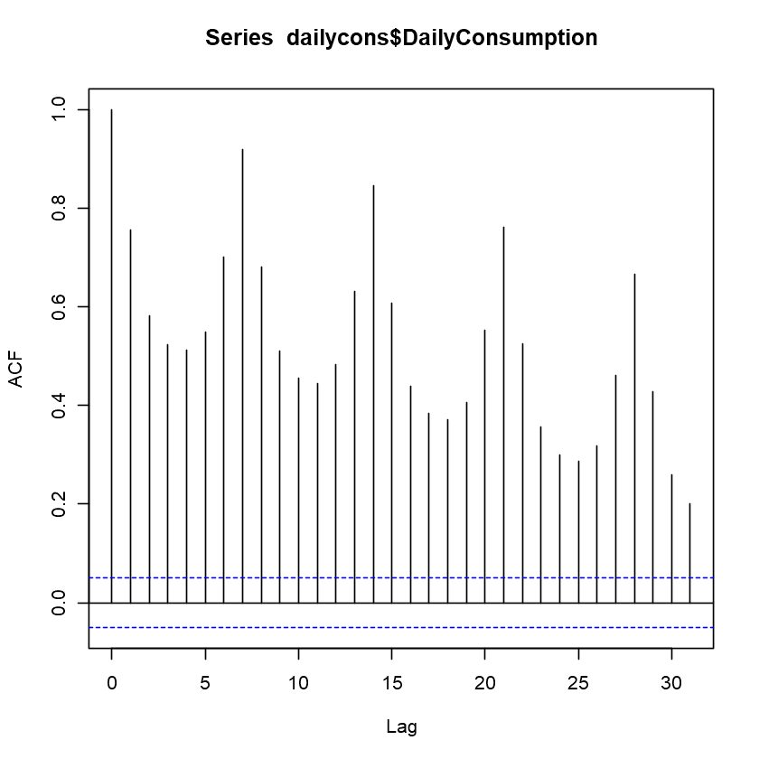

```r
acf(dailycons$DailyConsumption)
```

The autocorrelation plot supports the initial thought. There are high correlation in weekly seasonality which is represented by the peaks in 7th and multiplied lags. Also, there is high correlation in the last couple of days which is the 1st, 2nd lags.

Considering the high evidence of weekly seasonality and in order to stationarize the data, I have decided to build the model on seasonally differenced data which means the data is manipulated as the differences from sameweekday to next.

On the manipulated data, I have built a seasonal ARIMA model with 1 autoregressive , 1 moving average, 1 seasonal autoregressive and 1 seasonal moving average terms.

```r
# We want to predict the upcoming 2 days from the last day in the data.
# It is practical to set a variable to hold an indicative day such as the last day in data.
# Note that I update the .csv which holds the data everyday manually by hand.
lastDay = dailycons[.N, Date]
lastDay

a = ts(diff(dailycons$DailyConsumption, lag=7), frequency = 7)

model = arima(a, order=c(1,0,1), seasonal = c(1,0,1))
model

forecast = predict(model, n.ahead = 2)$pred
forecast = as.numeric(forecast)


forecastPeriod = seq.Date(from = lastDay + days(1), to = lastDay + days(2), by = "day")
forecastPeriod = data.table(Date = forecastPeriod)

forecastPeriod[, Result:=0]

forecastPeriod[Date == lastDay + days(1), Result:=dailycons[Date== lastDay - days(6), DailyConsumption] + forecast[1]]
forecastPeriod[Date == lastDay + days(2), Result:=dailycons[Date== lastDay - days(5), DailyConsumption] + forecast[2]]
forecastPeriod
```

2021-02-11

```
Call:
arima(x = a, order = c(1, 0, 1), seasonal = c(1, 0, 1))

Coefficients:
         ar1      ma1    sar1     sma1  intercept
      0.9677  -0.0570  0.2136  -0.9842   145.7469
s.e.  0.0072   0.0284  0.0273   0.0071   313.5370

sigma^2 estimated as 209518510:  log likelihood = -16465.27,  aic = 32942.54
```

| Date | Result |
| --- | --- |
| 2021-02-12 | 849591.0 |
| 2021-02-13 | 802547.7 |

We can evaluate the model with analyzing the residuals. On the graphs below, the residuals seem stationary and autocorrelation plots show some lags are barely significant. I will say that the model is adequate. There are probably better parameter combinations, however I tried a few and this was the best option. Maybe, some advanced algorithms such as grid search could yield better parameter combinations.

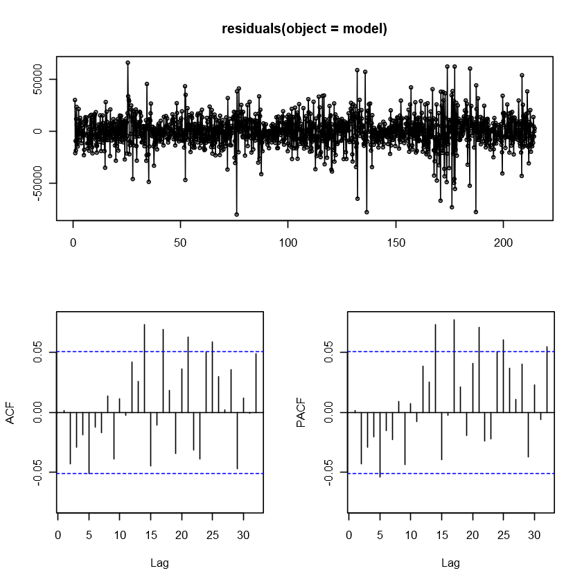

```r
tsdisplay(residuals(object = model))
```

Lastly, using the aggregate daily forecasts and the hour multipliers, I obtained hourly forecasts.

```r
lastDay

forecastPeriod[Date == lastDay + days(2), Result]
hourlyForecasts = forecastPeriod[Date == lastDay + days(2), Result] *
                    unlist(hourMultipliers[, 1 + wday(lastDay + days(2)), with = F], use.names = F)
hourlyForecasts
```

2021-02-11

802547.69002765

1. 32950.8558831711

2. 31198.8874277232

3. 29967.8056654594

4. 29088.8880418667

5. 28708.3651439564

6. 28666.3395906503

7. 29012.657065637

8. 29535.9847005685

9. 31319.0505144525

10. 33450.2671152922

11. 35062.803861484

12. 36458.2813927037

13. 36202.9365080864

14. 36841.0061314353

15. 36733.9483045298

16. 36053.754635183

17. 35628.8076707443

18. 35662.036657156

19. 36620.6759328627

20. 36363.6405713221

21. 35402.6001839447

22. 34705.2629175773

23. 34032.8550222108

24. 32879.9790896328

# 3. Evaluating the Results

In order to recreate the forecasting period, I can iteratively train the model with only the necessary information and try to get the result I had got in the competition process. The results could differ with my submissions due to updates in data.

Also, I decided on this model above as final after a few days of the start and the first submission of this model was 4th of February. So, in this testing, I think that it is more reasonable to exclude the days I have not submitted with this model. To clarify, those first days were forecasted with only autoregressive 1 model without seasonality and it did not perform as well as this model. Since I didn't submit those days with this model, testing the model for those days seems to me as not right.

```r
# Creating a data table to store forecasts and observed values.
forecastPeriod = consump[Date >= as.Date("2021-02-04") & Date <= as.Date("2021-02-13"), .(Date, Hour, Consumption)]
tempDT = fread("RealTimeConsumptionFeb1213.csv")

colnames(tempDT) = c("Date", "Hour", "Consumption")


tempDT[,Date:=as.Date(tempDT[,Date], format = "%d.%m.%Y")]
tempDT[,Consumption:=gsub(',','',Consumption)]
tempDT[,Consumption:=as.numeric(tempDT[,Consumption])]

forecastPeriod = rbind(forecastPeriod, tempDT)
forecastPeriod[, Forecast:=0]
```

```r
days = forecastPeriod[Hour=="01:00", Date]

for(i in 1:length(days)){
    tempDailyCons = dailycons[Date <= days[i] - days(2),]

    a = ts(diff(tempDailyCons$DailyConsumption, lag=7), frequency = 7)

    model = arima(a, order=c(1,0,1), seasonal = c(1,0,1))

    forecast = predict(model, n.ahead = 2)$pred
    forecast = as.numeric(forecast)

    tempday = (tempDailyCons[Date == days[i] - days(7), DailyConsumption] + forecast[2]) *
        unlist(hourMultipliers[, wday(days[i]) + 1, with = F], use.names = F)

    forecastPeriod[Date == days[i], Forecast:= tempday]
}
forecastPeriod
```

In the 10 plots below, there are the forecasts and realized values of electricity consumption of the days of forecasting period. It can be seen that in many of the days hour multipliers approach holds and behaviour of hours is similar. In some days, there are differences. I think those difference could be explained with temperature values. Also, it can be seen that it either overestimated or underestimated. This is probably because of the error of the daily aggregate forecast errors which affects the all hours of the day.

After the plots, I do performance analysis.

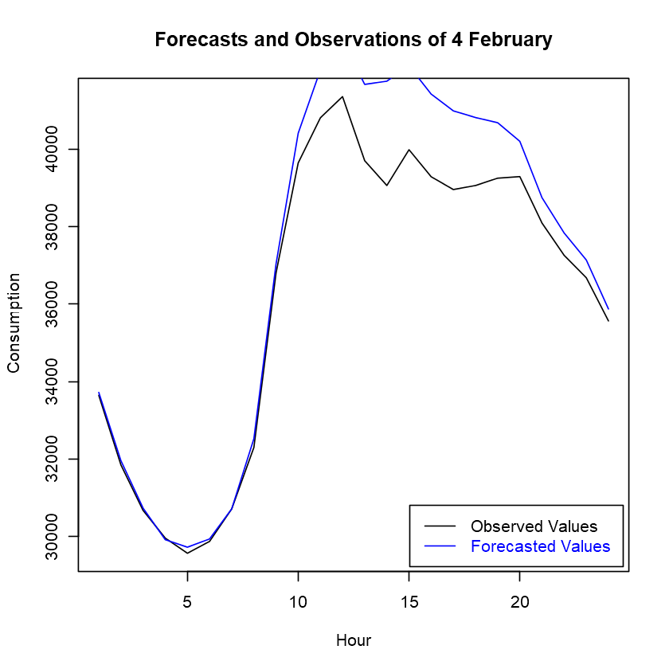

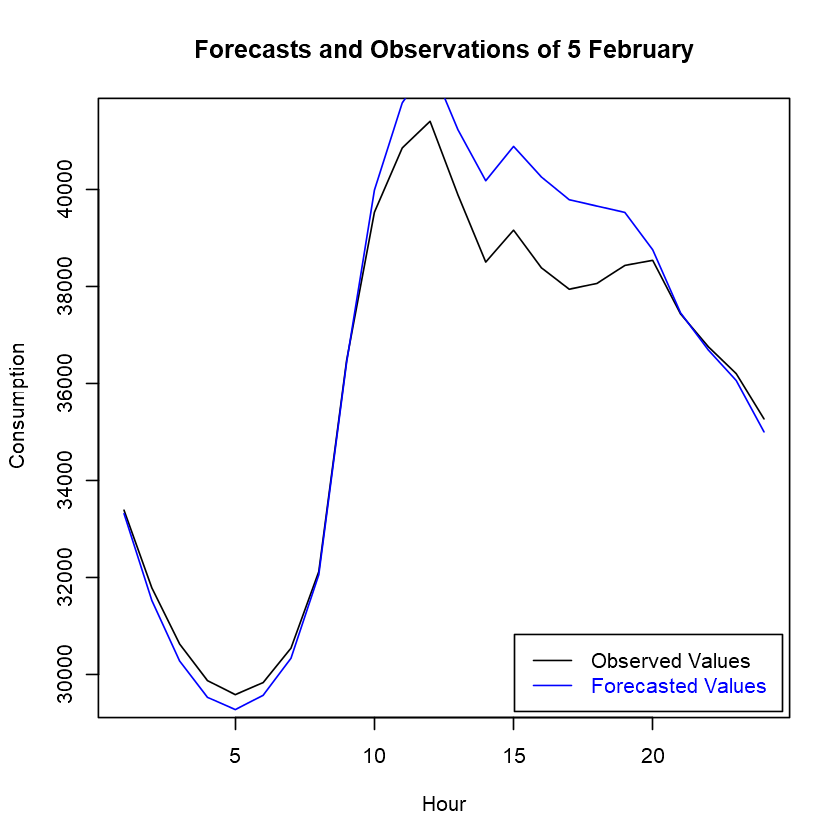

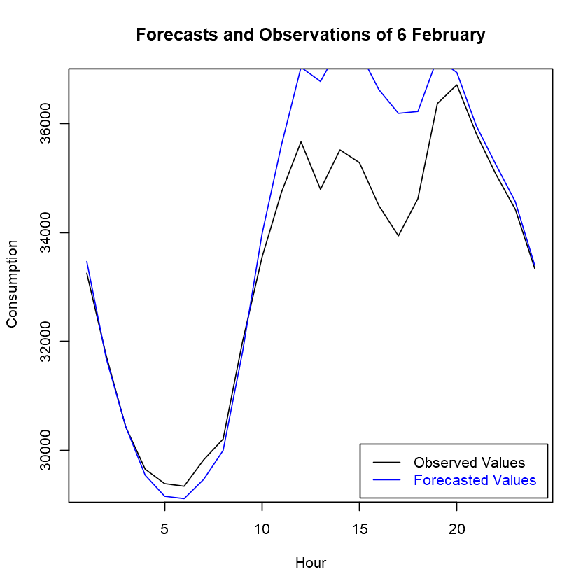

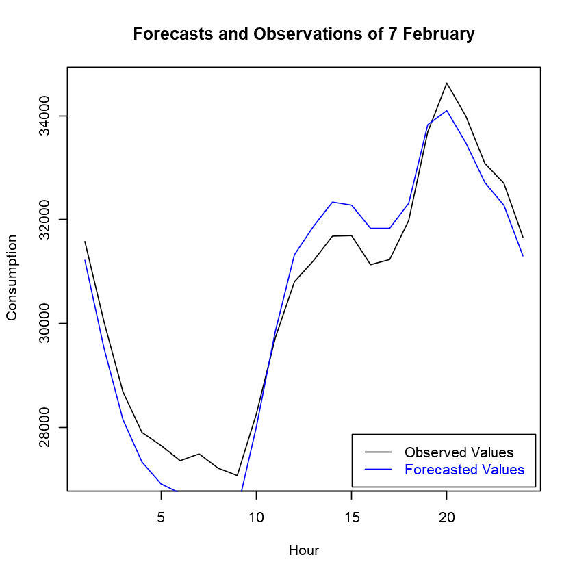

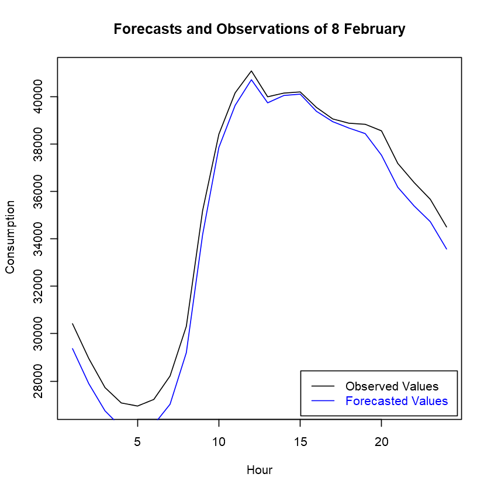

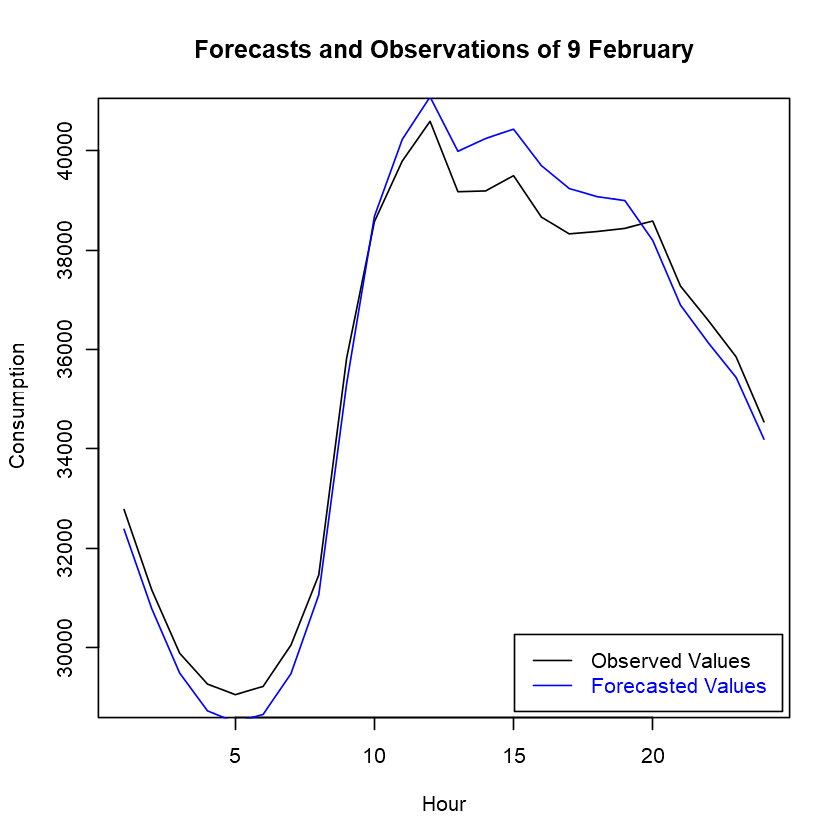

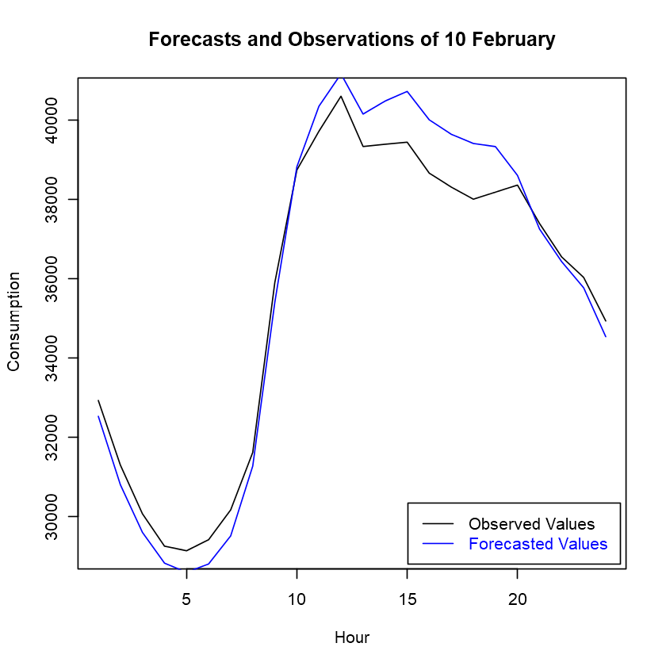

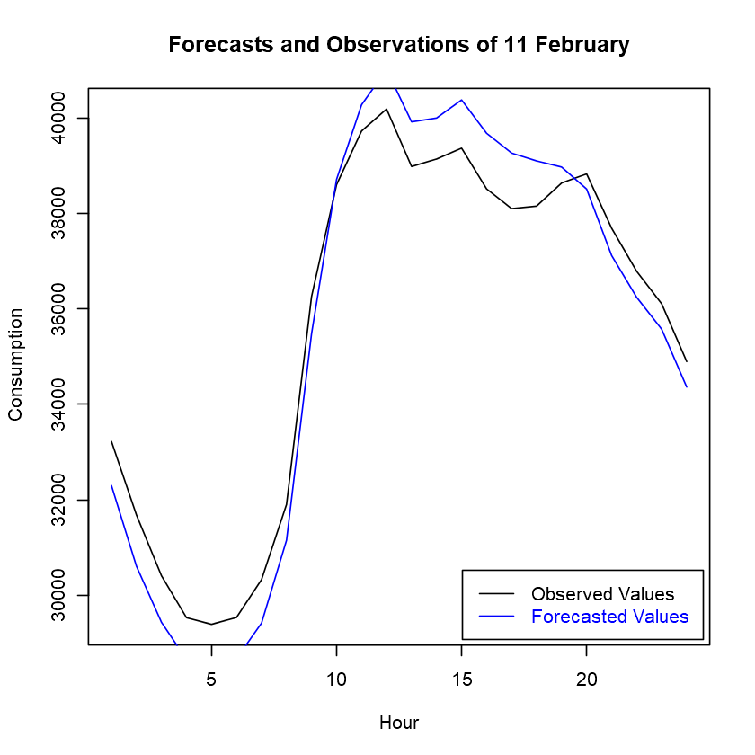

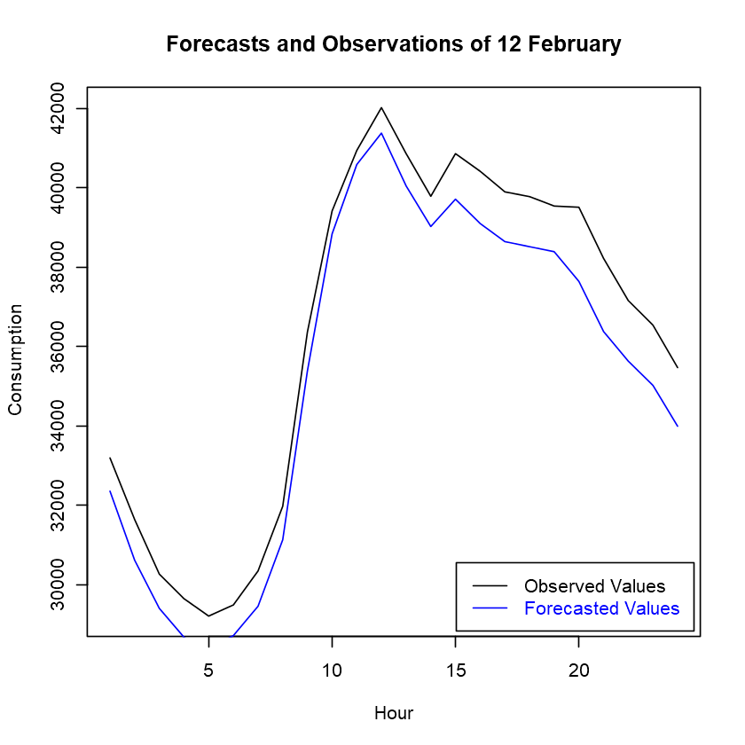

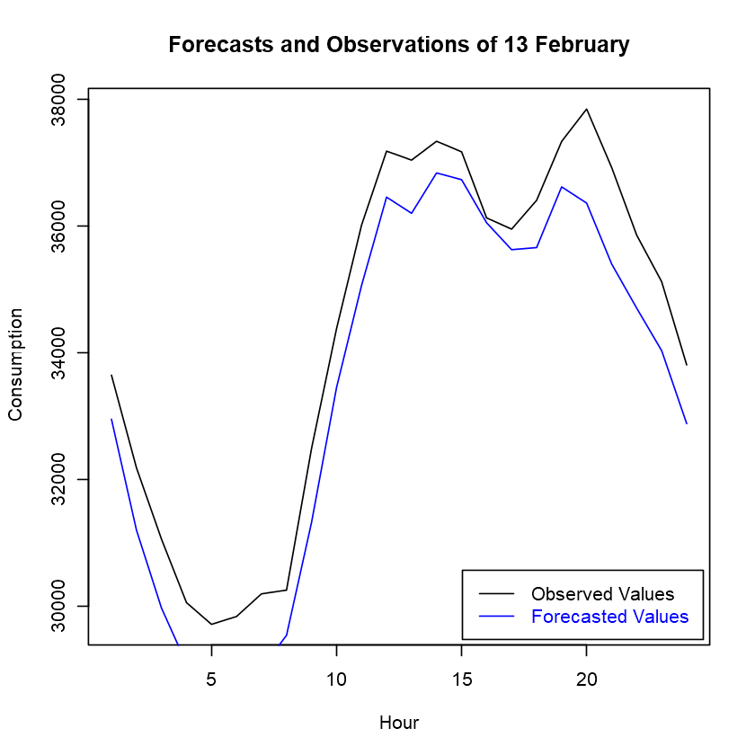

```r
for(i in 1:10){
    plot(forecastPeriod[Date == days[i], Consumption], type = "l", xlab="Hour", ylab="Consumption",
        main= paste("Forecasts and Observations of",i+3, "February"))
    lines(forecastPeriod[Date == days[i], Forecast], col= "blue")
    legend("bottomright", col = c("black", "blue"), text.col = c("black", "blue")
       , legend = c("Observed Values", "Forecasted Values"),
       inset = c(0.01, 0.01), lty = c(1,1))
}
```

### Performance Analysis

```r
accu = function(actual, forecast){
    n = length(actual)
    error = actual - forecast
    mean = mean(actual)
    sd = sd(actual)
    FBias = sum(error)/sum(actual)
    MAPE = sum(abs(error/actual)) / n
    RMSE = sqrt(sum(error^2) / n)
    MAD = sum(abs(error)) / n
    WMAPE = MAD / mean
    l = data.frame(n, mean, sd, FBias, MAPE, RMSE, MAD, WMAPE)
    return(l)
}

overallAccuracy = accu(forecastPeriod[,Consumption], forecastPeriod[,Forecast])

Date = "Overall"
dailyAccuracy = cbind(Date, overallAccuracy)

for(i in 1:length(days)){
    tempdailyAc = accu(forecastPeriod[Date == days[i], Consumption],
                        forecastPeriod[Date == days[i], Forecast])
    Date = as.factor(days[i])
    temprow = cbind(Date, tempdailyAc)
    dailyAccuracy = rbind(dailyAccuracy, temprow)


}

dailyAccuracy
```

| Date | n | mean | sd | FBias | MAPE | RMSE | MAD | WMAPE |
| --- | --- | --- | --- | --- | --- | --- | --- | --- |
| Overall | 240 | 34838.77 | 4065.797 | 0.0020306956 | 0.02128747 | 909.5953 | 745.6981 | 0.02140426 |
| 2021-02-04 | 24 | 36225.13 | 4005.511 | -0.0246618951 | 0.02301573 | 1223.9413 | 896.7531 | 0.02475500 |
| 2021-02-05 | 24 | 35849.09 | 3848.322 | -0.0134646608 | 0.01809540 | 944.5544 | 681.5654 | 0.01901207 |
| 2021-02-06 | 24 | 33338.66 | 2398.036 | -0.0187009613 | 0.02143534 | 1075.7703 | 738.3136 | 0.02214587 |
| 2021-02-07 | 24 | 30517.39 | 2338.087 | 0.0047966585 | 0.01687732 | 535.7263 | 506.9547 | 0.01661199 |
| 2021-02-08 | 24 | 35030.61 | 5138.284 | 0.0204801246 | 0.02226755 | 816.0865 | 717.4314 | 0.02048012 |
| 2021-02-09 | 24 | 35506.58 | 4009.675 | -0.0008689768 | 0.01563069 | 602.4509 | 555.7818 | 0.01565292 |
| 2021-02-10 | 24 | 35565.47 | 3947.519 | -0.0053545352 | 0.01772673 | 755.1918 | 637.5006 | 0.01792471 |
| 2021-02-11 | 24 | 35664.53 | 3813.395 | 0.0031274599 | 0.02209865 | 815.5169 | 769.7310 | 0.02158253 |
| 2021-02-12 | 24 | 36359.00 | 4414.774 | 0.0291882248 | 0.02935664 | 1126.3936 | 1061.2546 | 0.02918822 |
| 2021-02-13 | 24 | 34331.18 | 2873.715 | 0.0259733146 | 0.02637063 | 951.8650 | 891.6946 | 0.02597331 |

As it can be seen on the table above, the model performs quite well. Bias changes signs, so it means that the model is not constantly overpredicting or underpredicting. Also, WMAPE values are quite low which is a good indicator of low error.

# 4. Conclusions and Comments

All in all, seasonal time series model would perform well on the electricity consumption of Turkey. Though, sudden temperature changes would not be possible to predict with pure time series models, the performance of the models during stable periods are quite good as seen above. The special days or holidays are also not possible to model with pure time series models, they require further study. Because the aim of this project was to forecast a period in the start of February, there weren't any need to model for special/holiday days.

In the way I forecasted, I assumed that the hour distribution of daily consumption is the same in the close proximity of target days and I built the a seasonal ARIMA model for forecasting daily aggregate level and then divided the daily level to hours. Also, I replaced the outliers with a baseline approach. As, tested on this report and the project competition. Overall, the model performed well.

While seasonal ARIMA performed well, I am in sorrow due to not working with the temperatures. I wanted to build different models with the consideration of temperature. I wanted to study and implement some models such as SARIMA with regressors or even neural networks; but the busy schedule of finals period didn't allow me to. While I believe what I did for this project is adequate, there is also great possibility for many more approaches, methods.

# 5. Github Link for Forecasting Code Alone

https://github.com/BU-IE-360/fall20-buraknurerdem/blob/gh-pages/files/Project/IE360%20Group%2011%20-%20BurakNurErdem%20Project%20Code%20Alone.txt